# Introduction to logistic regression

### Abhigyan Kishor

#### Summary

Logistic regression involves modeling a regression problem to predict a binary outcome. Since our output is discrete, i.e. either 1 (event) or 0 (non-event), we use the **Bernoulli distribution** to compute the likelihood.

$$p(y_n|\mu_n) = \text{Bernoulli}(y_n|\mu_n) =
\mu_n^{y_n}(1-\mu_n)^{(1-y_n)}$$

In logistic regression, we are predicting the probability of the event occurring (event probability). Since this probability must be bounded between 0 and 1, we cannot predict $\mu$ directly using linear techniques. Instead we apply a **logit transformation** to our linear predictor to limit the output to the range [0,1].

$$\eta = \text{logit}(\mu) = \log\left[\frac{\mu}{1-\mu}\right]\quad \eta
\in (-\infty,\infty)\\
\mu = \text{logit}^{-1}(\eta) = \frac{\exp(\eta)}{1+\exp(\eta)} \quad
\mu \in [0,1]$$

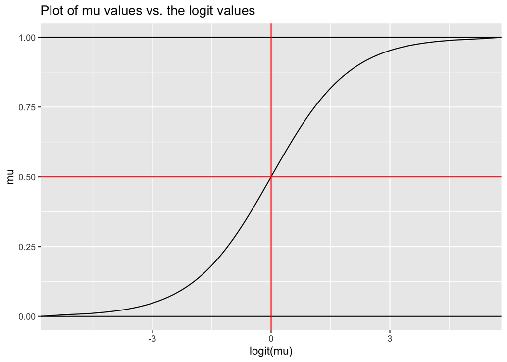

In the case of logistic regression, we **do not apply derivative adjustment** for the transformation. This is because the The event probability is deterministically known if we know the input and the 𝜷's.

We can consider the likelihood as a binomial distribution with trial size = 1. This way we can see that such a model **does not have a** $\sigma$ **value**. This is because for 1 trial it is impossible give a value for variance.

Therefore we only need to learn the unknown linear model coefficients ( $\beta$ ). We will assume they can be modeled as **independent Gaussian distributions** with mean $\mu_{\beta}$ and standard deviation $\tau_{\beta}$. Thus the final model can be summarized as:

$$p(y_n|\mu_n) \sim \text{Bernoulli}(y_n|\mu_n)\\
\mu = \text{logit}^{-1}(\eta) \\
\eta = X\beta\\
p(\beta) = \prod_{d=0}^D(\text{normal}(\beta_d |
\mu_{\beta},\tau_{\beta}))$$

#### Questions:

1. Consider the following transformations. which is best suited to replace logit transformation used for logistic regression?
   1. 1/x
   2. log(x)
   3. tanh(x)
   4. none of the above :)

Answer: tanh(x)

2. [True/False] For the same number of training points, a linear regression model will have greater precision than a logistic regression model.

Answer: True